# 检验斯特鲁普效应现象

- Q1
- Q2
- Q3
- Q4
- Q5
- Q6

```python
import pandas as pd
import numpy as np
import matplotlib.pyplot as plt
%matplotlib inline
```

```python
df = pd.read_csv('/Users/seattlehibiscus/Downloads/stroopdata.csv')
df.head()
```

|  | Congruent | Incongruent |
| --- | --- | --- |
| 0 | 12.079 | 19.278 |
| 1 | 16.791 | 18.741 |
| 2 | 9.564 | 21.214 |
| 3 | 8.630 | 15.687 |
| 4 | 14.669 | 22.803 |

### Q1: 自变量及因变量分别是什么?

在该问题中，自变量是颜色与文字相匹配的列表及颜色与文字不匹配的列表，因变量是参与者说出同等大小列表中的墨色名称的时间。

### Q2: 该任务假设集，用数学符号定义零假设及对立假设。选择的统计检验的类型。

**$H_{0}$**: $μ_{same}$ = $μ_{diff}$  
**$H_{1}$**: $μ_{same}$ ≠ $μ_{diff}$

**Note**:

- $μ_{same}$为颜色与文字匹配的所用时间总体参数均值，$μ_{diff}$为颜色与文字不匹配的所用时间总体参数均值。零假设为颜色与文字不匹配对参与者所用时间没有影响，对立假设是假设会对所用时间有影响。
- 在该假设集中，由于是同一组参与者接受两次不同的测验，因此属于相关样本，且将要检验的是配对观测值之差的均值是否等于目标值，因此选择配对t检验。同时该假设侧重于确定经干扰后的数据是否相同，因此该问题选择双侧配对T检验。
- 使用t检验的假设前提：1 作为相关样本，参与者之间是相互独立的 2 每组因变量服从正态分布

### Q3: 该数据集的描述性统计

```python
same = df['Congruent']
diff = df['Incongruent']
```

```python
# 两组数据的均值
same_mean = same.mean()
diff_mean = diff.mean()
same_mean, diff_mean
```

```
(14.051125000000004, 22.01591666666667)
```

```python
# 两组数据的中位数
same_median = same.median()
diff_median = diff.median()
same_median, diff_median
```

```
(14.3565, 21.0175)
```

```python
df.describe()
```

|  | Congruent | Incongruent |
| --- | --- | --- |
| count | 24.000000 | 24.000000 |
| mean | 14.051125 | 22.015917 |
| std | 3.559358 | 4.797057 |
| min | 8.630000 | 15.687000 |
| 25% | 11.895250 | 18.716750 |
| 50% | 14.356500 | 21.017500 |
| 75% | 16.200750 | 24.051500 |
| max | 22.328000 | 35.255000 |

```python
# 两组数据的标准差
df.describe().loc['std',:]
```

```
Congruent      3.559358
Incongruent    4.797057
Name: std, dtype: float64
```

### Q4: 样本数据可视化

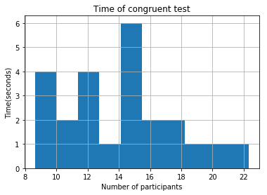

```python
df['Congruent'].hist()
plt.ylabel('Time(seconds)')
plt.xlabel('Number of participants')
plt.title('Time of congruent test')
```

- 从以上直方图可以看出，大概范围在8秒多到22秒多之间，在14至15秒左右大概有六人，人数最多。

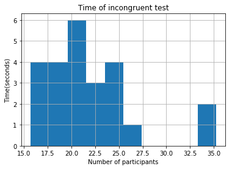

```python
df['Incongruent'].hist()
plt.ylabel('Time(seconds)')
plt.xlabel('Number of participants')
plt.title('Time of incongruent test')
```

- 从以上直方图可以看出，人数分布最多的区间在20至21秒内，人数同样为6人，同时该组数据中有两个异常值大于33秒。

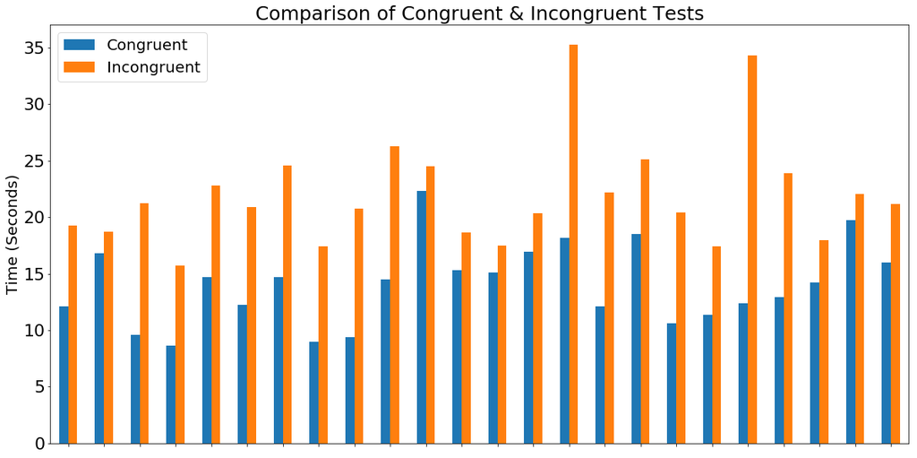

```python
df.plot(y=["Congruent", "Incongruent"], kind="bar",figsize=(20,10))
plt.title('Comparison of Congruent & Incongruent Tests', fontsize=25);
plt.ylabel('Time (Seconds)', fontsize=20)
plt.xticks(fontsize=20, visible=False)
plt.yticks(fontsize=22)
plt.legend(prop={'size':20});
```

- 从以上的两组数据的比较可以看出，颜色与文字相匹配的参与者所花时间全部都小于颜色与文字不匹配所花时间，无一例外。

### Q5: 统计测试，置信水平及关键统计值，测试结果及结论

- 置信水平设置为95%

```python
# 自由度
DF = len(df)-1
DF
```

```
23
```

```python
# 计算T临界值
from scipy.stats import t as pt
t_crit = pt.ppf(1-0.05/2, DF)
t_crit
```

```
2.0686576104190406
```

```python
# 计算两组数据的差值
df['diff'] = df['Incongruent'] - df['Congruent']
df.head()
```

|  | Congruent | Incongruent | diff |
| --- | --- | --- | --- |
| 0 | 12.079 | 19.278 | 7.199 |
| 1 | 16.791 | 18.741 | 1.950 |
| 2 | 9.564 | 21.214 | 11.650 |
| 3 | 8.630 | 15.687 | 7.057 |
| 4 | 14.669 | 22.803 | 8.134 |

```python
# 计算该数据集的T值
import math
t = df['diff'].mean()/(df['diff'].std()/math.sqrt(len(df)))
t
```

```
8.020706944109957
```

- 计算出的T值（8.020）远大于置信水平95%时的T临界值（2.068），T值处于拒绝域内，因此可以拒绝零假设。
- 在α = 0.05时拒绝零假设，对于颜色与文字相匹配所需的时间是与颜色与文字不相匹配所需时间是不同的，颜色与文字不匹配会影响参与者辨别时间。

### Q6: 导致所观察到的效应的原因是什么？你是否能想到会取得类似效应的替代或类似任务？

- 可能导致该效应的原因是识别单词及辨别颜色是两种不同类型的认知过程，两者同时进行必然会影响认知过程的时间，类似的
- 图-词干扰任务可以作为类似任务。在图-词干扰中，向被试者呈现图与干扰词，二者同时呈现，或者先呈现图，然后呈现干扰词，要求被试者读出干扰词。例如向被试者呈现圆形中的汉字“方”，正方形中“圆”字等，任务是要求被试忽略图形，命名图形里面的汉字。